# An Unsupervised Approach Over Tweets Related With Daily Agenda

## Motivation & Observations

Nowadays, as an observation, since we are experiencing extreme conditions, people are more interested in the daily agenda of their country. I suppose that this tendency is more observable in the country where the pandemy is more severe.

In a television program, a Turkish woman from Italy while telling about their life under quarantine mentioned that they were watching regularly the speeches of politicians everyday on 6pm in order to hear good or bad news. After that, they spend the tonight to discuss the daily news with their friends on telephone.

We can propose that social media is the medium of today where people discuss daily news and express their reactions on them. Twitter is the most effective one for us, developers, among other social media as being the place where all can participate freely expressing their ideas and also providing a decent API for facilitating dataset creation.

Though it is not coronavirus specific, it is critically important for policy makers to effectively measure the reactions of the public on specific topics, news or agenda. This would be important for dealing with Coronavirus Pandemy. For one thing, in these days, governments should make their people comply with precautions, even the extreme ones like curfew, while not making them desperate about future thereby stabilizing economic indicators over a course of time. This difficult task can only be achieved with continually observing the mood of the people with effective measurement techniques and tools.

This project is an attempt to analyze if we can extract the topics related with daily agenda on which people talk with their interaction rates on social media.

#### Problem Statement

Political actions would not be effective when the people's ideas remain undiscovered. I want to make different reactions more discoverable

**General Notice:** I would like to deliver the project as an end-to-end runnable notebook but there were two obstacles for this.

- Twitter datasets cannot be shared publicly
- There is no effective Turkish NLP other than Zemberek which is only available on Java, which makes me create a seperate project for preprocessing tweets, explained later in detail.

However, I will try to do my best to showcase what is done and what is missing

## Dataset Preparation

### Data Collection Strategy

After deciding to collect the data from Twitter, it is the next challenge how to decide on the query to choose tweets. I want to catch a perspective in which the ideas and the reactions of all parties are included. As the routine on Twitter, there are always hot topics and related hashtags people express their opinions on. However, those hot topics are biassed in terms of specific topic they focus and the people segments interested in the topic.

I want to create a dataset that reflects the opinion of the public as a whole as much as possible. The hashtags that FoxTV Ana Haber announces for their viewers were chosen, since these hashtags create an environment for all to tweet their reactions. Even though the audience watching FoxTV Ana Haber is also tend to create a specific segment of the society, I am assuming due to high rating rates and popularity that almost all of the society utilizes these hashtags when they want to say something about daily agenda. These hashtags are unique for each day and so popular which provides sufficient number of tweets.

The related code is under *twitterApi* notebook.

### Data Preprocessing

It is very important to mention that Turkish NLP is still so hard. Fortunately, Zemberek NLP Java Library is working in a decent way with useful appraoches. The following steps are taken for preprocessing:

- **Remove Urls and Numbers**
- **Normalization:** Noisy text normalization is applied, which is offered by Zemberek for noisy texts
- **Tokenization:** Zemberek is utilized
- **Lemmatization:** Zemberek is utiilzed
- **Remove Stop Words**

### Example Tweet Json

**Before Preprocessing:**

```
{
    "full_text": "@fatihportakal hemen hemen hergün 70’li sayılar veriliyor ölenler için bu bir tesadüf müdür #suepheduymuyorum diyemeyeceğim kanun vs bir hükümmü var acaba ayar veriliyor..???"
}
```

**After Preprocessing:**

```
{
    "lemmatized_text": "hemen hemen hergün 70 sayı vermek ölmek için bu bir tesadüf müdür demek kânun vs bir hüküm mü var acaba ayar vermek",
    "tokenized_text": "hemen hemen hergün 70 li sayılar veriliyor ölenler için bu bir tesadüf müdür diyemeyeceğim kanun vs bir hüküm mü var acaba ayar veriliyor",
    "processed_text": "hemen hemen hergün 70 sayı vermek ölmek tesadüf müdür demek kânun vs hüküm ayar vermek"
}
```

**Note:** Though other fields are kept, `processed_text` is used for analysis

The related code under zemberek-nlp-tools folder under the repository

### Notes on Twitter API

- Twitter does not allow datasets including tweets to be publicly available. Only ids of tweets can be share publicly, which have everyone somehow retrieve the tweets from Twitter API
- Standart search on Twitter API retrieves the within the last 7-day period.

### Related Work & Resources

It turns out that the following [Kaggle Notebook](https://www.kaggle.com/maksimeren/covid-19-literature-clustering#Dimensionality-Reduction-with-t-SNE) about COVID-19 Literature Clustering is parallel with my project. Some ideas and codes are adapted from there.

#### Word Embedding Training

Training word2vec, the following [repository](https://github.com/akoksal/Turkish-Word2Vec) from @akoksal is benefited. For including the recent terms about coronavirus, a number of news taken from [NTV Coronavirus Page](https://www.ntv.com.tr/corona-virus) and added to the wikipedia text corpus

```python
import pandas as pd
import numpy as np
import matplotlib.pyplot as plt
import seaborn as sns
from gensim.models import KeyedVectors
import math
```

```python
tweet_df = pd.read_csv('data/tweet_data.csv')
```

```python
tweet_df[['id', 'hashtag_id']].groupby(by="hashtag_id").count()
```

| hashtag_id | id |
| --- | --- |
| #biralkışda | 6911 |
| #duysesimi | 8265 |
| #gittimgeldim | 7280 |
| #hepsinitopla | 6227 |
| #işaş | 3446 |
| #kabuledilemez | 7838 |
| #neyinnesi | 4693 |
| #sesverin | 5046 |
| #veresiyedefteri | 4067 |
| #çağrımvar | 6781 |
| #şüpheduymuyorum | 5880 |

#### Days and Corresponding Hasgtags

**Note:** No hashtags for weekends

- 2 Nisan 2020 : #şüpheduymuyorum
- 3 Nisan 2020 : #duysesimi
- 6 Nisan 2020 : #neyinnesi (Erdoğan Açıklama 19:00)
- 7 Nisan 2020 : #biralkışda
- 8 Nisan 2020 : #hepsinitopla
- 9 Nisan 2020 : #kabuledilemez
- 10 Nisan 2020 : #neredenbulacağım
- 13 Nisan : #gittimgeldim
- 14 Nisan : #işaş
- 15 Nisan : #veresiyedefteri
- 16 Nisan : #çağrımvar
- 17 Nisan : #sesverin
- 20 Nisan : #çıldıracağım
- 21 Nisan : #nereyevarır
- 22 Nisan : #çocuklarınmutluluğu
- 23 Nisan : #halkınmeclisi
- 24 Nisan : #akıllarazarar

```python
hashtags_map = {
    '02.04': '#şüpheduymuyorum', # 2 Nisan 2020 Perşembe
    '03.04': '#duysesimi', # 3 Nisan 2020 Cuma
    '06.04': '#neyinnesi', # 6 Nisan 2020 Pazartesi
    '07.04': '#biralkışda', # 7 Nisan 2020 Salı
    '08.04': '#hepsinitopla', # 8 Nisan 2020 Çarşamba
    '09.04': '#kabuledilemez', # 9 Nisan 2020 Perşembe
    '10.04': '#neredenbulacağım', # 10 Nisan 2020 Cuma
    '13.04': '#gittimgeldim', # 13 Nisan 2020 Pazartesi
    '14.04': '#işaş', # 14 Nisan 2020 Salı
    '15.04': '#veresiyedefteri', # 15 Nisan 2020 Çarşamba
    '16.04': '#çağrımvar', # 16 Nisan 2020 Perşembe
    '17.04': '#sesverin', # 17 Nisan 2020 Cuma
    '20.04': '#çıldıracağım', # 20 Nisan 2020 Pazartesi
    '21.04': '#nereyevarır', # 21 Nisan 2020 Salı
    '22.04': '#çocuklarınmutluluğu', # 22 Nisan 2020 Çarşamba
    '23.04': '#halkınmeclisi', # 23 Nisan 2020 Perşembe
    '24.04': '#akıllarazarar' # 24 Nisan 2020 Cuma
}

hashtags_by_day = {
    '02.04': tweet_df[tweet_df['hashtag_id'] == '#şüpheduymuyorum'], # 2 Nisan 2020 Perşembe
    '03.04': tweet_df[tweet_df['hashtag_id'] == '#duysesimi'], # 3 Nisan 2020 Cuma
    '06.04': tweet_df[tweet_df['hashtag_id'] == '#neyinnesi'], # 6 Nisan 2020 Pazartesi
    '07.04': tweet_df[tweet_df['hashtag_id'] == '#biralkışda'], # 7 Nisan 2020 Salı
    '08.04': tweet_df[tweet_df['hashtag_id'] == '#hepsinitopla'], # 8 Nisan 2020 Çarşamba
    '09.04': tweet_df[tweet_df['hashtag_id'] == '#kabuledilemez'], # 9 Nisan 2020 Perşembe
    '10.04': tweet_df[tweet_df['hashtag_id'] == '#neredenbulacağım'], # 10 Nisan 2020 Cuma
    '13.04': tweet_df[tweet_df['hashtag_id'] == '#gittimgeldim'], # 13 Nisan 2020 Pazartesi
    '14.04': tweet_df[tweet_df['hashtag_id'] == '#işaş'], # 14 Nisan 2020 Salı
    '15.04': tweet_df[tweet_df['hashtag_id'] == '#veresiyedefteri'], # 15 Nisan 2020 Çarşamba
    '16.04': tweet_df[tweet_df['hashtag_id'] == '#çağrımvar'], # 16 Nisan 2020 Perşembe
    '17.04': tweet_df[tweet_df['hashtag_id'] == '#sesverin'], # 17 Nisan 2020 Cuma
    '20.04': tweet_df[tweet_df['hashtag_id'] == '#çıldıracağım'], # 20 Nisan 2020 Pazartesi
    '21.04': tweet_df[tweet_df['hashtag_id'] == '#nereyevarır'], # 21 Nisan 2020 Salı
    '22.04': tweet_df[tweet_df['hashtag_id'] == '#çocuklarınmutluluğu'], # 22 Nisan 2020 Çarşamba
    '23.04': tweet_df[tweet_df['hashtag_id'] == '#halkınmeclisi'], # 23 Nisan 2020 Perşembe
    '24.04': tweet_df[tweet_df['hashtag_id'] == '#akıllarazarar'] # 24 Nisan 2020 Cuma
}
```

#### Choose the Day

I am choosing a hashtag to work first

```python
hashtag_day = "06.04"
hashtag_id = hashtags_map[hashtag_day]
```

```python
tweet_df = hashtags_by_day[hashtag_day]
```

### Vectorization

Two different methods are under discussion to be tested vectorizing tweets

#### TF-IDF Vectorization

In this method, we do not exclude mentions and hashtags, they can be represented effectively with respect to tf and idf values.

This has a drawback here. Since documents here are tweets, which are very short ones. Term Frequency of TF-IDF will generally be 1.

#### Vectorize Using Word Embeddings

Word embeddings are effective in terms of reflecting the meaning of words but, here, noisy text, mentions and hashtags can make them ineffective to cover all the things in a typical tweet.

This vectorization is removed from the notebook since tdidf outperformed after testing

```python
from sklearn.feature_extraction.text import TfidfVectorizer
def vectorize(text, maxx_features):

    vectorizer = TfidfVectorizer(max_features=maxx_features)
    X = vectorizer.fit_transform(text)
    return X


corpus = tweet_df['processed_text']
X = vectorize(corpus, 2 ** 10)
X.shape
```

```
(4693, 1024)
```

### Dimension Reduction with PCA

The data is presumably noisy, it is a decent approach to apply dimension reduction keeping 95% variance. Hopefully, this will remove some noise/outliers from the data, and make the clustering problem easier for k-means.

```python
from sklearn.decomposition import PCA
from sklearn.cluster import KMeans


pca = PCA(n_components=0.95, random_state=42)

#tf-idf vectorization
X_reduced= pca.fit_transform(X.toarray())
X_reduced.shape
```

```
(4693, 761)
```

### How to choose k (number of clusters)

Elbow method is utilized for choosing k

```python
from sklearn.cluster import KMeans
from sklearn import metrics
from scipy.spatial.distance import cdist
from tqdm import tqdm

# run kmeans with many different k
distortions = []
K = range(2, 50)
for k in tqdm(K):
    k_means = KMeans(n_clusters=k, random_state=42)
    k_means.fit(X_reduced)
    distortions.append(sum(np.min(cdist(X_reduced, k_means.cluster_centers_, 'euclidean'), axis=1)) / X.shape[0])
    #print('Found distortion for {} clusters'.format(k))
```

```python
X_line = [K[0], K[-1]]
Y_line = [distortions[0], distortions[-1]]

sns.set(rc={'figure.figsize':(8,6)})

# Plot the elbow
plt.plot(K, distortions, 'b-')
plt.plot(X_line, Y_line, 'r')
plt.xlabel('k')
plt.ylabel('Distortion')
plt.title('The Elbow Method for optimal k ({}-{})'.format(hashtag_id, hashtag_day))
plt.savefig("graphs/elbow_method_{}.png".format(hashtag_day))
plt.show()
```

Since this process take some time I will include graphs as images which are generated before for the datasets on different days

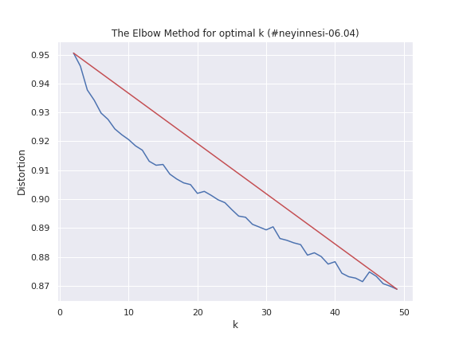

```python
from IPython.display import Image
Image(filename='graphs/elbow_method_06.04.png')
```

**Choose k = 20 for TF-IDF Approach**

From the diagrams, the values btw 15-25 can be ok. 20 will be the point of choice.

```python
k = 20
kmeans = KMeans(n_clusters=k, random_state=42)
y_pred = kmeans.fit_predict(X_reduced)
tweet_df['y'] = y_pred
```

#### Visualize Data Using T-SNE Algorithm

```python
from sklearn.manifold import TSNE

tsne = TSNE(verbose=1, perplexity=50, random_state=42)
X_embedded = tsne.fit_transform(X.toarray())
```

```
[t-SNE] Computing 151 nearest neighbors...
[t-SNE] Indexed 4693 samples in 0.677s...
[t-SNE] Computed neighbors for 4693 samples in 38.422s...
[t-SNE] Computed conditional probabilities for sample 1000 / 4693
[t-SNE] Computed conditional probabilities for sample 2000 / 4693
[t-SNE] Computed conditional probabilities for sample 3000 / 4693
[t-SNE] Computed conditional probabilities for sample 4000 / 4693
[t-SNE] Computed conditional probabilities for sample 4693 / 4693
[t-SNE] Mean sigma: 0.353342
[t-SNE] KL divergence after 250 iterations with early exaggeration: 82.406898
[t-SNE] KL divergence after 1000 iterations: 2.405059
```

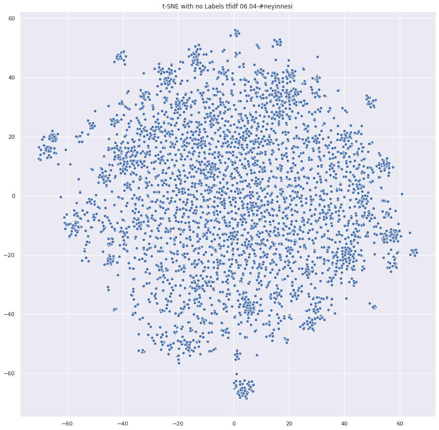

```python
# sns settings
sns.set(rc={'figure.figsize':(15,15)})

# colors
palette = sns.color_palette("bright", 1)

# plot
sns.scatterplot(X_embedded[:,0], X_embedded[:,1], palette=palette)
plt.title('t-SNE with no Labels tfidf {}-{}'.format(hashtag_day, hashtag_id))
plt.savefig("t-sne_{}.png".format(hashtag_day))
plt.show()
```

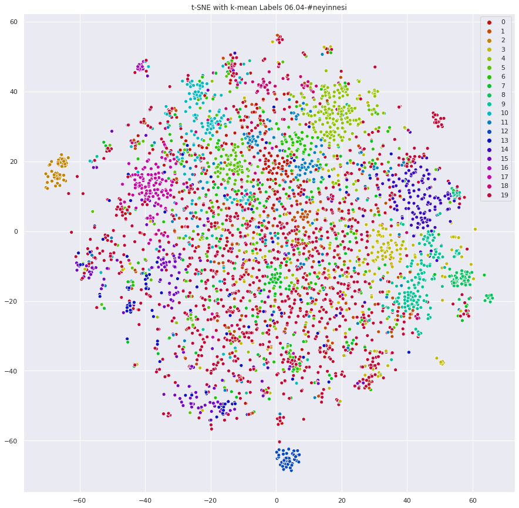

```python
%matplotlib inline
# sns settings
sns.set(rc={'figure.figsize':(15,15)})

# colors
palette = sns.hls_palette(k, l=.4, s=.9)

# plot
sns.scatterplot(X_embedded[:,0], X_embedded[:,1], hue=y_pred, legend='full', palette=palette)
plt.title('t-SNE with k-mean Labels {}-{}'.format(hashtag_day, hashtag_id))
plt.savefig("graphs/clusters_tsne_{}.png".format(hashtag_day))
plt.show()
```

```python
tweet_df.to_csv('data/tweet_df_clustered.csv')
```

### Understand What Cluster is About

#### LDA (Latent Dirichlet Allocation)

This approach is mainly adapted from the [Kaggle Notebook](https://www.kaggle.com/maksimeren/covid-19-literature-clustering#Dimensionality-Reduction-with-t-SNE) In that notebook, this method is used to extract topics from cluster of papers. In my case tweets are much shorter than papers, which would be problematic. LDA is adjusted to take care of the ngrams of 1 to 5 words

```python
from sklearn.decomposition import LatentDirichletAllocation
from sklearn.feature_extraction.text import CountVectorizer
```

```python
# Functions for printing keywords for each topic
def selected_topics(model, vectorizer, top_n=3):
    current_words = []
    keywords = []

    for idx, topic in enumerate(model.components_):
        words = [(vectorizer.get_feature_names()[i], topic[i]) for i in topic.argsort()[:-top_n - 1:-1]]
        for word in words:
            if word[0] not in current_words:
                keywords.append(word)
                current_words.append(word[0])

    keywords.sort(key = lambda x: x[1])
    keywords.reverse()
    return_values = []
    for ii in keywords:
        return_values.append(ii[0])
    return return_values

def lda_clustering(k, col):

    vectorizers = []

    for ii in range(0, k):
        # Creating a vectorizer
        vectorizers.append(CountVectorizer(ngram_range=(1, 5), stop_words=None, lowercase=True, token_pattern='[a-zA-ZâüğşıöçÜĞŞİÇÖ\-][a-zA-ZâüğşıöçÜĞŞİÇÖ\-]{2,}'))

    vectorized_data = []

    for current_cluster, cvec in enumerate(vectorizers):
        try:
            vec_data = cvec.fit_transform(tweet_df.loc[tweet_df[col] == current_cluster, 'processed_text'])
            vectorized_data.append(vec_data)
        except Exception as e:
            print("Not enough instances in cluster: " + str(current_cluster))
            print(e)
            vectorized_data.append(None)

    # number of topics per cluster
    NUM_TOPICS_PER_CLUSTER = 5

    lda_models = []
    for ii in range(0, k):
        # Latent Dirichlet Allocation Model
        lda = LatentDirichletAllocation(n_components=NUM_TOPICS_PER_CLUSTER, max_iter=10, learning_method='online',verbose=False, random_state=42)
        lda_models.append(lda)

    clusters_lda_data = []

    for current_cluster, lda in enumerate(lda_models):
        # print("Current Cluster: " + str(current_cluster))

        if vectorized_data[current_cluster] != None:
            clusters_lda_data.append((lda.fit_transform(vectorized_data[current_cluster])))

    all_keywords = []
    for current_vectorizer, lda in enumerate(lda_models):
        # print("Current Cluster: " + str(current_vectorizer))

        if vectorized_data[current_vectorizer] != None:
            all_keywords.append(selected_topics(lda, vectorizers[current_vectorizer]))

    return all_keywords
```

#### TF-IDF Vectorization - LDA Topic Clustering

```python
k = 20
col = 'y'

all_keywords = lda_clustering(k, col)
```

### How to measure social interaction over clustered tweets

This is a question that should be answered later on. I suppose the mean values of favorites and retweet counts over a cluster indicates significancy of the topic. I am using an arbitrary formula to combine different measures of a cluster. This score will make us can sort cluster with respect to their importance

Other fields are also added to `summary_df` for inspection

```
    Score = favorite_mean * retweet_mean * log(user_follower_mean) * log(num_of_tweets)
```

```python
summary_df_arr = []

for cluster_id, cluster_df in tweet_df.groupby(by="y"):
    row = {}
    row['cluster_id'] = cluster_id
    row['keywords'] = " : ".join(all_keywords[cluster_id])
    row['num_of_tweets'] = cluster_df.shape[0]
    row['favorite_mean'] = cluster_df['favorite_count'].mean()
    row['retweet_mean'] = cluster_df['retweet_count'].mean()
    row['user_follower_mean'] = cluster_df['user_follower_count'].mean()
    row['favorite_sum'] = cluster_df['favorite_count'].sum()
    row['retweet_sum'] = cluster_df['retweet_count'].sum()
    row['user_follower_sum'] = cluster_df['user_follower_count'].sum()
    row['score'] = row['favorite_mean'] * row['retweet_mean'] * np.log1p(row['user_follower_mean']) * np.log1p(row['num_of_tweets'])
    summary_df_arr.append(row)

summary_df = pd.DataFrame(summary_df_arr)
```

```python
pd.set_option('display.max_colwidth', -1)
summary_df.sort_values(by="score", ascending=False)
```

|  | cluster_id | keywords | num_of_tweets | favorite_mean | retweet_mean | user_follower_mean | favorite_sum | retweet_sum | user_follower_sum | score |
| --- | --- | --- | --- | --- | --- | --- | --- | --- | --- | --- |
| 14 | 14 | tekalif : tekalif milliye : milliye : tekalifsi milliye : tekalifsi | 184 | 33.951087 | 7.972826 | 4140.423913 | 6247 | 1467 | 761838 | 11769.235411 |
| 9 | 9 | atatürk : havalimanı : atatürk havalimanı | 214 | 28.920561 | 5.911215 | 5203.233645 | 6189 | 1265 | 1113492 | 7856.740956 |
| 3 | 3 | çovid : tamzamanı : japonya : pttmaske : vaka | 290 | 23.551724 | 3.534483 | 7508.548276 | 6830 | 1025 | 2177479 | 4214.463410 |
| 19 | 19 | puan : yan : trafik : ziyaselçuk : cumhurbaşkanı : hastane : gün : eğitim : yasak : tcmeb : akşam : sayın : ülke : iyi : virüs | 1454 | 10.854195 | 2.872765 | 2010.061210 | 15782 | 4177 | 2922629 | 1727.324559 |
| 18 | 18 | vergi : lık : internet bağlat damga vergi alındı : bağlat : devlet : yardım : uçak : yap : maske : para : ver : fatura : maaş | 105 | 13.885714 | 3.590476 | 1121.980952 | 1458 | 377 | 117808 | 1633.033655 |
| 16 | 16 | bit : modül : süreç : öğretici : kararname : öğretici durum göz bulundurulmadık : göster usta : kurs | 23 | 8.826087 | 9.130435 | 163.956522 | 203 | 210 | 3771 | 1307.599260 |
| 13 | 13 | iste : risk : yan : tedavi : fizik tedavi : öğrenci : ödev : güvence : hak : bekle : devlet | 156 | 10.871795 | 3.076923 | 982.448718 | 1696 | 480 | 153262 | 1165.554123 |
| 15 | 15 | ses : hak : drfahrettinkoca : duy : sağlikbakanlığı : lütfen : duyur : tekniker | 215 | 8.023256 | 4.358140 | 152.897674 | 1725 | 937 | 32873 | 946.592992 |
| 2 | 2 | okul : ihtiyaç : sürekli : işçi : güvenlik : uabakanlığı : sürekli güvenlik ihtiyaç fethigurer : rterdoğan tbmmresmi süleymansoylu ziyaselçuk | 89 | 9.179775 | 4.876404 | 46.988764 | 817 | 434 | 4182 | 779.732031 |
| 7 | 7 | insan : gör : yaş : fakülte : yap : yok : ülke : durum : devlet : millet | 215 | 5.348837 | 2.669767 | 1492.334884 | 1150 | 574 | 320852 | 561.019423 |
| 4 | 4 | maske : para : devlet : ücretsiz : bedava : ücretsiz maske | 255 | 8.149020 | 1.329412 | 3787.207843 | 2078 | 339 | 965738 | 494.981542 |
| 11 | 11 | devlet : başvur : gelir : ver : yap : ülke : esnaf : durum | 194 | 8.262887 | 1.536082 | 472.412371 | 1603 | 298 | 91648 | 412.270666 |
| 6 | 6 | para : ver : halk : yok : toplanan : vatandaş : devlet : gün | 182 | 3.478022 | 2.021978 | 2343.291209 | 633 | 368 | 426479 | 284.282889 |
| 12 | 12 | kamu : kamulaştırıl : hizmet : edil rterdoğan : istihdam edil rterdoğan drfahrettinkoca : radyoloji : taşeronradyolojiyekadro : tekniker kamu istihdam edil drfahrettinkoca : radyoloji hizmet : istihda… | 68 | 3.426471 | 1.882353 | 333.514706 | 233 | 128 | 22679 | 158.739980 |
| 1 | 1 | yap : haber : sağlık : haber yap : yol : hastane : belediye : gün : chp | 204 | 5.210784 | 0.416667 | 5542.107843 | 1063 | 85 | 1130590 | 99.625852 |
| 0 | 0 | yardım : chp : devlet : belediye : sosyal : yok : ihtiyaç : yap : gelir : sayın | 200 | 4.665000 | 0.655000 | 353.965000 | 933 | 131 | 70793 | 95.153992 |
| 8 | 8 | vaka : gsbpersonelalımı vaka : herkesenasipolmaz : infazdaayrim : atatürk havalimanı : havalimanı : katliam : kırmızıotobüsyollarda : yarbay mehmet alkan : alkan dur infazdaayrim katliam atatürk | 79 | 1.746835 | 1.240506 | 16563.189873 | 138 | 98 | 1308492 | 92.250499 |
| 17 | 17 | kredi : faiz : destek : banka : iste : erteleme : borç : sicil | 150 | 1.520000 | 0.706667 | 679.406667 | 228 | 106 | 101911 | 35.152264 |
| 5 | 5 | yok : gelir : gelir yok : kira : para : abi : yap : yardım : devam | 229 | 1.432314 | 0.419214 | 472.144105 | 328 | 96 | 108121 | 20.112130 |
| 10 | 10 | maaş : işsizlik : işsizlik maaş : öde : kira : fatura : çalış : bağış : çık | 187 | 1.117647 | 0.283422 | 317.481283 | 209 | 53 | 59369 | 9.560186 |

### Visualization Using WordCloud

```python
from wordcloud import WordCloud
import re

def show_wordcloud(cluster_id):
    cluster_text = " ".join(list(tweet_df[tweet_df['y'] == cluster_id]['processed_text'].values))
    cluster_text = re.sub(r'#\S+', '', cluster_text)
    cluster_text = re.sub(r'@\S+', '', cluster_text)
    cluster_text = re.sub(r'[^\w\s]',' ',cluster_text)

    wordcloud = WordCloud(width = 1200, height = 800,
                background_color ='white',
                min_font_size = 10).generate(cluster_text)

    # plot the WordCloud image
    plt.figure(figsize = (8, 8), facecolor = None)
    plt.imshow(wordcloud)
    plt.axis("off")
    plt.tight_layout(pad = 0)

    plt.show()
```

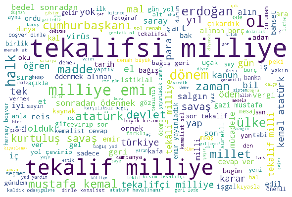

```python
show_wordcloud(14)
```

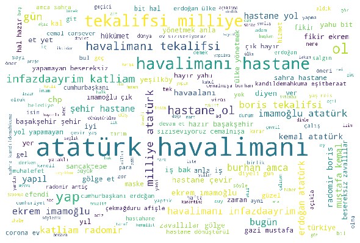

```python
show_wordcloud(9)
```

### Sentiment Analysis

As another step I tried to include sentiment analysis to understand tweet clusters using SentiTurkNet. Sentiment analysis on tweet clusters would be significant contribution to find out what people feel on the topic of the cluster. However, this was not a successful attempt.

The idea was using SentiTurkNet lexicon labelling words as positive, negative and neutral.

```python
# I created a dictionary on twitterSegment notebook
import pickle
with open('senti_dict', 'rb') as f:
    senti_dict = pickle.loads(f.read())
```

```python
def analyze_tweet(tweet_text):
    res = {
        'positive': 0,
        'negative': 0,
        'neutral': 0
    }

    map_ = {
        'positive': 2,
        'negative': 1,
        'neutral': 0
    }

    count = 0

    for word in tweet_text.split():
        if word in senti_dict:
            count += 1
            f = senti_dict[word]
            if f['label'] == 'p':
                res['positive'] += 1
            elif f['label'] == 'n':
                res['negative'] += 1
            elif f['label'] == 'o':
                res['neutral'] += 1

    if count < 1:
        return map_['neutral']

    keys = list(res.keys())
    keys.sort(key=lambda key: -1 * res[key])


    return map_[keys[0]]
```

```python
tweet_df['sentiment_type'] = tweet_df['processed_text_v2'].apply(analyze_tweet)
```

```python
tweet_df[['id', 'sentiment_type']].groupby(by='sentiment_type').count()
```

| sentiment_type | id |
| --- | --- |
| 0 | 4519 |
| 1 | 51 |
| 2 | 123 |

### Measure Clustering Performance

We will convert the problem into supervised learning splitting the data into train and test sets. Stochastic Gradient Descent algorithm trained to learn how to label tweets into clusters, then results will be tested

```python
# function to print out classification model report
def classification_report(model_name, test, pred):
    from sklearn.metrics import precision_score, recall_score
    from sklearn.metrics import accuracy_score
    from sklearn.metrics import f1_score

    print(model_name, ":\n")
    print("Accuracy Score: ", '{:,.3f}'.format(float(accuracy_score(test, pred)) * 100), "%")
    print("     Precision: ", '{:,.3f}'.format(float(precision_score(test, pred, average='macro')) * 100), "%")
    print("        Recall: ", '{:,.3f}'.format(float(recall_score(test, pred, average='macro')) * 100), "%")
    print("      F1 score: ", '{:,.3f}'.format(float(f1_score(test, pred, average='macro')) * 100), "%")
```

```python
# Splitting data

from sklearn.model_selection import train_test_split

# test set size of 20% of the data and the random seed 42 <3
X_train, X_test, y_train, y_test = train_test_split(X.toarray(),y_pred, test_size=0.2, random_state=42)

print("X_train size:", len(X_train))
print("X_test size:", len(X_test), "\n")
```

```
X_train size: 3754
X_test size: 939
```

```python
from sklearn.model_selection import cross_val_score
from sklearn.model_selection import cross_val_predict
from sklearn.linear_model import SGDClassifier

# SGD instance
sgd_clf = SGDClassifier(max_iter=10000, tol=1e-3, random_state=42, n_jobs=4)
# train SGD
sgd_clf.fit(X_train, y_train)

# cross validation predictions
sgd_pred = cross_val_predict(sgd_clf, X_train, y_train, cv=3, n_jobs=4)

# print out the classification report
classification_report("Stochastic Gradient Descent Report (Training Set)", y_train, sgd_pred)
```

```
Stochastic Gradient Descent Report (Training Set) :

Accuracy Score:  87.906 %
     Precision:  90.308 %
        Recall:  87.284 %
      F1 score:  88.663 %
```

```python
# cross validation predictions
sgd_pred = cross_val_predict(sgd_clf, X_test, y_test, cv=3, n_jobs=4)

# print out the classification report
classification_report("Stochastic Gradient Descent Report (Test Set)", y_test, sgd_pred)
```

```
Stochastic Gradient Descent Report (Test Set) :

Accuracy Score:  81.044 %
     Precision:  86.999 %
        Recall:  79.419 %
      F1 score:  81.879 %
```

```python
sgd_cv_score = cross_val_score(sgd_clf, X.toarray(), y_pred, cv=10)
print("Mean cv Score - SGD: {:,.3f}".format(float(sgd_cv_score.mean()) * 100), "%")
```

```
Mean cv Score - SGD: 90.092 %
```

### Let's Analyze Other Days

```python
def analyze_day(tweet_df):
    corpus = tweet_df['processed_text']
    X = vectorize(corpus, 2 ** 10)

    pca = PCA(n_components=0.95, random_state=42)

    #tf-idf vectorization
    X_reduced= pca.fit_transform(X.toarray())
    X_reduced.shape

    k = 20
    kmeans = KMeans(n_clusters=k, random_state=42)
    y_pred = kmeans.fit_predict(X_reduced)
    tweet_df['y'] = y_pred
    col = 'y'

    all_keywords = lda_clustering(k, col)

    summary_df_arr = []

    for cluster_id, cluster_df in tweet_df.groupby(by="y"):
        row = {}
        row['cluster_id'] = cluster_id
        row['keywords'] = " : ".join(all_keywords[cluster_id])
        row['num_of_tweets'] = cluster_df.shape[0]
        row['favorite_mean'] = cluster_df['favorite_count'].mean()
        row['retweet_mean'] = cluster_df['retweet_count'].mean()
        row['user_follower_mean'] = cluster_df['user_follower_count'].mean()
        row['favorite_sum'] = cluster_df['favorite_count'].sum()
        row['retweet_sum'] = cluster_df['retweet_count'].sum()
        row['user_follower_sum'] = cluster_df['user_follower_count'].sum()
        row['score'] = row['favorite_mean'] * row['retweet_mean'] * np.log1p(row['user_follower_mean']) * np.log1p(row['num_of_tweets'])
        summary_df_arr.append(row)

    summary_df = pd.DataFrame(summary_df_arr)

    pd.set_option('display.max_colwidth', -1)

    best_3 = summary_df[['cluster_id', 'score']].sort_values(by="score", ascending=False)['cluster_id'].values[0:3]

    for i in best_3:
        show_wordcloud(i)
    return summary_df.sort_values(by="score", ascending=False)
```

```python
hashtag_day = "07.04"
hashtag_id = hashtags_map[hashtag_day]
```

```python
tweet_df = hashtags_by_day[hashtag_day]
```

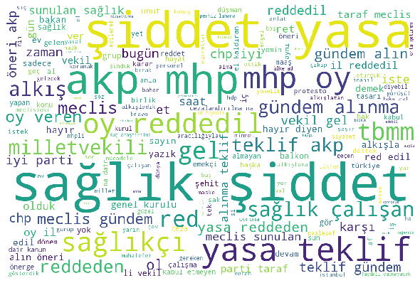

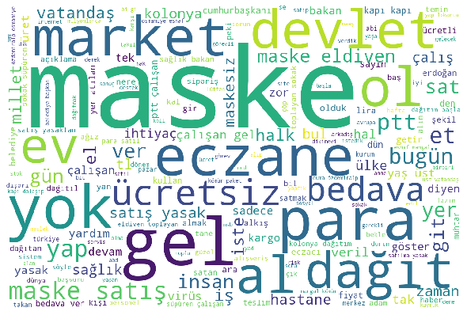

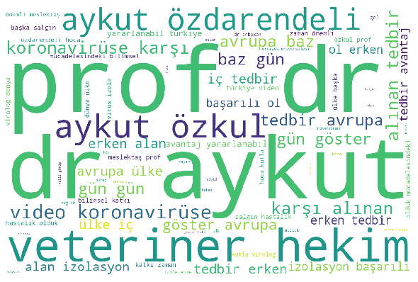

|  | cluster_id | keywords | num_of_tweets | favorite_mean | retweet_mean | user_follower_mean | favorite_sum | retweet_sum | user_follower_sum | score |
| --- | --- | --- | --- | --- | --- | --- | --- | --- | --- | --- |
| 8 | 8 | sağlık : şiddet : şiddet yasa : sağlık şiddet : yasa | 140 | 53.457143 | 13.721429 | 6323.921429 | 7484 | 1921 | 885349 | 31770.299789 |
| 1 | 1 | maske : satış : market : yok : gel : para : eldiven : yap : eczane | 256 | 38.296875 | 4.789062 | 13333.101562 | 9804 | 1226 | 3413274 | 9666.524315 |
| 10 | 10 | tedbir : avrupa : gün : prof aykut : veteriner : veteriner hekim : hekim : aykut : üniversitesi : prof | 76 | 14.131579 | 6.342105 | 1873.210526 | 1074 | 482 | 142364 | 2933.810721 |
| 7 | 7 | gel : gün : olduk : sokak : alkış : yok : zor : fatihportakalyalnizdeğildir : belediye : yap | 2237 | 17.583371 | 2.483684 | 1493.635673 | 39334 | 5556 | 3341263 | 2462.275218 |
| 17 | 17 | eğitim : ücret : özel : yurt : ücretli öğretmen : ücretli : ses : öğretmen : mağdur : merkez : öğrenci : senet | 227 | 10.136564 | 5.118943 | 694.268722 | 2301 | 1162 | 157599 | 1843.663326 |
| 9 | 9 | insan : düşman : güzel : çalışan : gün : gel : banka : doğru | 288 | 14.760417 | 2.059028 | 4380.434028 | 4251 | 593 | 1261565 | 1444.042474 |
| 6 | 6 | çalışan : gece : gece gündüz : gündüz | 180 | 13.483333 | 2.261111 | 484.305556 | 2427 | 407 | 87175 | 980.214540 |
| 5 | 5 | vaka : saathiççıkma : kurul : sokak : çünküöbeklenenlider : çıkma | 341 | 8.398827 | 1.991202 | 13939.879765 | 2864 | 679 | 4753499 | 931.165012 |
| 14 | 14 | işçi : sağlık : temizlik : çalışan : asgari : alkış : gel | 172 | 6.406977 | 2.250000 | 1905.901163 | 1102 | 387 | 327815 | 561.116923 |
| 4 | 4 | yapan : görev : gel : alkış : çalışan : doğru : haber | 186 | 6.526882 | 1.451613 | 586.193548 | 1214 | 270 | 109032 | 315.976394 |
| 2 | 2 | drfahrettinkoca : atama : sağlık : hastane : bakan : iste : sağlık bakan : gün | 349 | 3.704871 | 1.882521 | 294.762178 | 1293 | 657 | 102872 | 232.453347 |
| 19 | 19 | çalışan : gel : market : sosyal : vakıf : sağlık : belediye : ptt : devam | 556 | 6.498201 | 0.809353 | 406.073741 | 3613 | 450 | 225777 | 199.814043 |
| 11 | 11 | saathiççıkma : vaka : çünküöbeklenenlider : halükleventadayasesver : saathiççıkma fatihportakalyalnizdeğildir halükleventadayasesver : iskuracansuyuyedekimd : dur alabil : dur alabil mandalizm | 60 | 3.216667 | 1.416667 | 39691.950000 | 193 | 85 | 2381517 | 198.362657 |
| 0 | 0 | zor : gün : çalışan : gel : çocuk : dışarı : kal : çalışma : lütfen : çık : vaka | 398 | 5.002513 | 0.864322 | 784.886935 | 1991 | 344 | 312385 | 172.636786 |
| 3 | 3 | infaz : cezaevi : karantina : personel : gel : gün | 120 | 5.708333 | 1.008333 | 285.008333 | 685 | 121 | 34201 | 156.129391 |
| 18 | 18 | alkış : iyi : hak : destek : gel : allah : bakan : ülke : devlet : yok : taraf : yap | 456 | 4.478070 | 0.769737 | 1130.605263 | 2042 | 351 | 515556 | 148.442463 |
| 12 | 12 | cinayet : affahayır affetmiyoruz affedensuçortağıdır : infaztasarısıniğericekin : affahayır : affahayır affetmiyoruz : affetmiyoruz : kayıplarımızıcın : emre : infaztasarısıniğericekin affahayır : inf… | 56 | 1.196429 | 1.714286 | 4460.267857 | 67 | 96 | 249775 | 69.682436 |
| 16 | 16 | yardım : devlet : yok : yap : sosyal : gel | 367 | 1.863760 | 0.572207 | 419.746594 | 684 | 210 | 154047 | 38.069115 |
| 15 | 15 | banka : haber : yap : kredi : doğru : faiz : gel : esnaf | 350 | 1.388571 | 0.345714 | 1299.585714 | 486 | 121 | 454855 | 20.174144 |
| 13 | 13 | işçi : elektrik üretim : elektrik : fatura : gel : kapalı : kredi | 96 | 0.520833 | 0.395833 | 210.531250 | 50 | 38 | 20211 | 5.049907 |

```python
analyze_day(tweet_df)
```

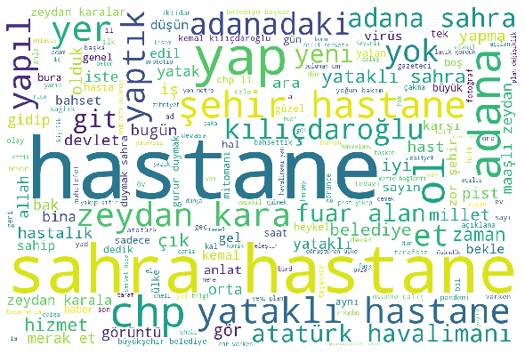

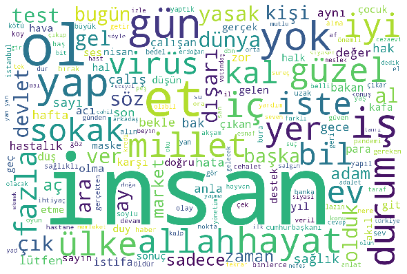

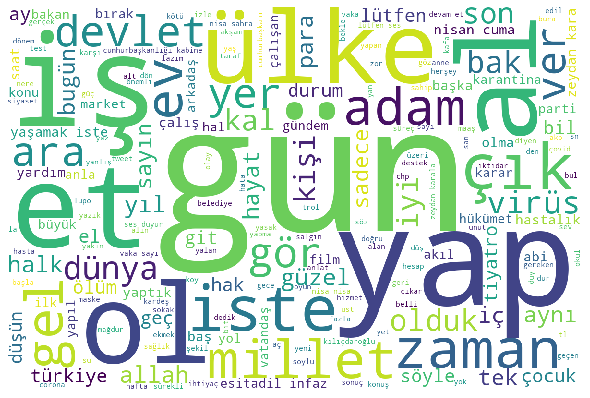

|  | cluster_id | keywords | num_of_tweets | favorite_mean | retweet_mean | user_follower_mean | favorite_sum | retweet_sum | user_follower_sum | score |
| --- | --- | --- | --- | --- | --- | --- | --- | --- | --- | --- |
| 18 | 18 | hastane : yataklı : yer : kılıçdaroğlu : sahra hastane : sahra | 192 | 49.958333 | 13.708333 | 3220.750000 | 9592 | 2632 | 618384 | 29113.005643 |
| 1 | 1 | insan : test : yap : sayı : gün : iyi : hayat : ver : güzel : hafta : yok | 310 | 29.377419 | 3.670968 | 1756.270968 | 9107 | 1138 | 544444 | 4624.866924 |
| 3 | 3 | nisa : maskeyok : survivor : lütfen : gün : çık : vaka : gör : iste : millet : ülke : tiyatro : güzel : yap | 2717 | 11.271991 | 6.149798 | 3076.812661 | 30626 | 16709 | 8359700 | 4402.823795 |
| 15 | 15 | soylu : istifa : bakan : karar : kabul : etme : istifa kabul | 241 | 17.630705 | 2.775934 | 2083.236515 | 4249 | 669 | 502060 | 2052.972223 |
| 7 | 7 | gün : yap : mağdur : iste : güzel : gel : çık : adam : git : abi : ses : başka | 567 | 10.463845 | 3.229277 | 1245.368607 | 5933 | 1831 | 706124 | 1527.559648 |
| 0 | 0 | drfahrettinkoca : iste : atama : sağlık : ağız : ağızvedissağlığına : ağızvedissağlığına atama | 219 | 4.739726 | 2.762557 | 140.383562 | 1038 | 605 | 30744 | 349.687552 |
| 6 | 6 | coronavirüs : maskelernerede : survivor : çovid : dolar : corona | 287 | 6.198606 | 1.233449 | 660.128920 | 1779 | 354 | 189457 | 281.169243 |
| 11 | 11 | sağlıkçı : ses : yetersiz alim : iste lütfen ses destek : ses duyurma çalış durmak : duyurma çalış sene bnlik : sağlıkçı atama çovid : çovid mücadele yetersiz alim : türkiye : bugün türkiye dünya : is… | 53 | 4.226415 | 2.547170 | 386.018868 | 224 | 135 | 20459 | 255.874705 |
| 8 | 8 | ısüzamahayır : okuma : zam : son : oturma oda okul yeni zam : okul : iste : alın halüklevent ahbapplatformu istinyeunivedu : alın halüklevent ahbapplatformu istinyeunivedu ısüzamahayır : hak alın halü… | 135 | 9.644444 | 1.266667 | 66.881481 | 1302 | 171 | 9029 | 253.126733 |
| 12 | 12 | erdoğan : süleyman soylu : soylu : bakan : süleyman | 250 | 5.000000 | 0.844000 | 3055.508000 | 1250 | 211 | 763877 | 187.122888 |
| 17 | 17 | sokak : yasak : çıkma : çıkma yasak | 331 | 5.830816 | 0.725076 | 1510.501511 | 1930 | 240 | 499976 | 179.674695 |
| 10 | 10 | ısüzamahayır : eğitimcilik anlayış kesinlik uymayan : kesinlik : kına ertelen iptal iste istinyeunivedu : iptal iste istinyeunivedu : ertelen iptal iste istinyeunivedu : iste atvcomtr : ısüzamahayır a… | 150 | 8.300000 | 0.860000 | 59.873333 | 1245 | 129 | 8981 | 147.149694 |
| 2 | 2 | yok : çalışan : yardım : hekim : para : maaş : ver : yap : cevap : aynı | 364 | 3.162088 | 0.881868 | 1001.173077 | 1151 | 321 | 364427 | 113.682978 |
| 13 | 13 | haber : hediye : sevin : yap : istifa : yok : karar | 180 | 4.944444 | 0.561111 | 1883.616667 | 890 | 101 | 339051 | 108.767899 |
| 4 | 4 | hafta : son : hafta son : bulaş | 208 | 4.855769 | 0.442308 | 683.576923 | 1010 | 92 | 142184 | 74.911246 |
| 19 | 19 | çernobil : yan : çovid : yangın : depremistanbul : felaket : dünya : chernobyl | 143 | 3.748252 | 0.517483 | 1784.552448 | 536 | 74 | 255191 | 72.177256 |
| 16 | 16 | git : gel : git gel | 317 | 4.012618 | 0.466877 | 541.460568 | 1272 | 148 | 171643 | 67.964184 |
| 5 | 5 | maske : eczane : mesaj : market : yok : gel : aynı : kişi | 375 | 2.552000 | 0.610667 | 677.282667 | 957 | 229 | 253981 | 60.245976 |
| 9 | 9 | çocuksusarsensusma saldayadokunma : saldayadokunma : felaketleri çocuksusarsensusma : çovid vaka : vaka bizbizeyeteriz : vaka : vaka bizbizeyeteriz yoladevam vaka : çovid vaka bizbizeyeteriz yoladevam… | 89 | 2.314607 | 0.235955 | 986.292135 | 206 | 21 | 87780 | 16.944657 |
| 14 | 14 | kredi : banka : ver : destek : devlet : yok : özel banka | 152 | 1.078947 | 0.217105 | 213.559211 | 164 | 33 | 32461 | 6.326104 |

```python
hashtag_day = "13.04"
hashtag_id = hashtags_map[hashtag_day]
tweet_df = hashtags_by_day[hashtag_day]
analyze_day(tweet_df)
```

[output not shown]

## Conclusion

As an overall observation, after clustering tweets, some clusters are significant with a spesific topic while some clusters are noisy in terms of the topics they include.

The day which we inspected in this notebook was 6 April. On this day, president Erdoğan give a speech on 19.00. In `summary_df` the most interacted tweet cluster seems to be related with what president Erdoğan says about *Tekalifi Milliye emirleri*, which is an interesting result that complies with the agenda. This topic was a significant one on that day.

On the other hand, though it is not perfect, my approach is successful on clustering tweets extracting different topic against which people reacted.

When we look at other days, twitter clusters seem to reveal hot topics. wordclouds may be an option to understand feelings of the people, though not so effective.

This work is far from conclusive but seems to have a potential to make improvements. I would like to discuss possible improvements.

- Vectorizing tweets with w2vec, only important words can be chosen using tf-idf approach
- Understanding clusters, most frequent ngrams or other methods might be more efficient, which should be tested.
- The clusters can be attempted to match with the news of the day
- Sentiment analysis can be integrated to analyze different tweet clusters